# Part2

```python
ratio_delay_arr.head()#show the top five rows
```

|  | Diverted | Cancelled | TailNum | Year | ArrDelay | DepDelay | year | Total_flight_delayed |
| --- | --- | --- | --- | --- | --- | --- | --- | --- |
| 0 | 0 | 0 | N808AW | 2000 | 7.0 | 0.0 | 1999.0 | 0 |
| 1 | 0 | 0 | N653AW | 2000 | 40.0 | 1.0 | 1999.0 | 1 |
| 3 | 0 | 0 | N806AW | 2000 | -7.0 | -2.0 | 1999.0 | 0 |
| 4 | 0 | 0 | N158AW | 2000 | -4.0 | -4.0 | 1987.0 | 0 |
| 5 | 0 | 0 | N656AW | 2000 | 47.0 | 3.0 | 1999.0 | 1 |

```python
ratio_delay_arr['age'] = ratio_delay_arr['Year']- ratio_delay_arr['year']
```

```python
ratio_delay_arr = ratio_delay_arr[(ratio_delay_arr['year'] <= ratio_delay_arr['Year']) | ratio_delay_arr['year'].isna()]
#take only rows when year of manufactuer less than or equals to Year of flight or when the year is Na's values.
```

```python
ratio_delay_arr['Age_category'] = ratio_delay_arr['Diverted'].copy()
ratio_delay_arr.loc[(ratio_delay_arr['age'] >=0 ) & (ratio_delay_arr ['age'] <=10),'Age_category'] = "0-10"
ratio_delay_arr.loc[(ratio_delay_arr['age'] >=11 ) & (ratio_delay_arr ['age'] <=20),'Age_category'] = "11-20"
ratio_delay_arr.loc[(ratio_delay_arr['age'] >=21 ) & (ratio_delay_arr ['age'] <=30),'Age_category'] = "21-30"
ratio_delay_arr.loc[(ratio_delay_arr['age'] >=31 ) & (ratio_delay_arr ['age'] <=40),'Age_category'] = "31-40"
ratio_delay_arr.loc[(ratio_delay_arr['age'] >=41 ) & (ratio_delay_arr ['age'] <=50),'Age_category'] = "41-50"
ratio_delay_arr.loc[ratio_delay_arr['age'].isna(),'Age_category'] = "NA"
#same as previously, where Age_category col will be created and denoted based on certain conditions of the age, same as above
```

```python
ratio_delay_arr =(ratio_delay_arr.groupby(['Year','Age_category']).agg(
    total_flight = ('Total_flight_delayed','count'),
    total_delay_flight = ('Total_flight_delayed','sum')).reset_index())
#it will perform aggregation and group it by Year and Age_category and then calculate the total_flight by count it and the total_delay_flight by sum it
```

```python
ratio_delay_arr['ratio_of_delay']= round(ratio_delay_arr['total_delay_flight']*100/ratio_delay_arr['total_flight'],1)#calculate the ratio_of_delay with that formula, same as above, and then round it with one decimal points
```

```python
ratio_delay_arr.head()#show the top 5 rows
```

|  | Year | Age_category | total_flight | total_delay_flight | ratio_of_delay |
| --- | --- | --- | --- | --- | --- |
| 0 | 2000 | 0-10 | 1270242 | 111455 | 8.8 |
| 1 | 2000 | 11-20 | 727408 | 58982 | 8.1 |
| 2 | 2000 | 21-30 | 73348 | 4694 | 6.4 |
| 3 | 2000 | 31-40 | 88995 | 5800 | 6.5 |
| 4 | 2000 | 41-50 | 2665 | 206 | 7.7 |

```python
colours_cus_7 =[]#create empty list
maxi_7=[]#create empty list
mini_7=[]#create empty list
#for y that is from 2000 to 2004,
# the "maxim_7" will contains the row index which contains the maximum of ratio_of_delay by using ratio_delay_arr data when the year is equal to y
# the "minim_7" will contains the row index which contains the minimum of ratio_of_delay by using ratio_delay_arr data when the year is equal to y
#custom_colour_7 => when the x is equal to maxim_7 (maximum index of row) it will be denoted as 'red',
#                => when the x is equal to minim_7 (minimum index of row) it will be denoted as 'green'
#                => otherwise it will denoted as 'gray'
# x is inside the index from the ratio_delay_arr when the year is equals to y
#then the custom_colour_7 that have been created before will be stored in colours_cus_7
#ma_7 is using the ratio_delay_arr data and to locate the maxim_7 (maximum index of row) and it will return the ratio_of_delay on that row index
#mi_7 is using the ratio_delay_arr data and to locate the minim_7 (minimum index of row) and it will return the ratio_of_delay on that row index
#ma_7 will be stored in maxi_7, while mi_7 will be stored in mini_7

for y in range (2000,2005):
    maxim_7= ratio_delay_arr[ratio_delay_arr['Year']==y]['ratio_of_delay'].idxmax()
    minim_7= ratio_delay_arr[ratio_delay_arr['Year']==y]['ratio_of_delay'].idxmin()
    custom_colour_7 = ['red' if x == maxim_7 else 'green' if x==minim_7 else 'gray' for x in (ratio_delay_arr[ratio_delay_arr["Year"]== y]).index]
    colours_cus_7.append(custom_colour_7)
    ma_7 = ratio_delay_arr.loc[maxim_7,'ratio_of_delay']
    mi_7 = ratio_delay_arr.loc[minim_7,'ratio_of_delay']
    maxi_7.append(ma_7)
    mini_7.append(mi_7)
```

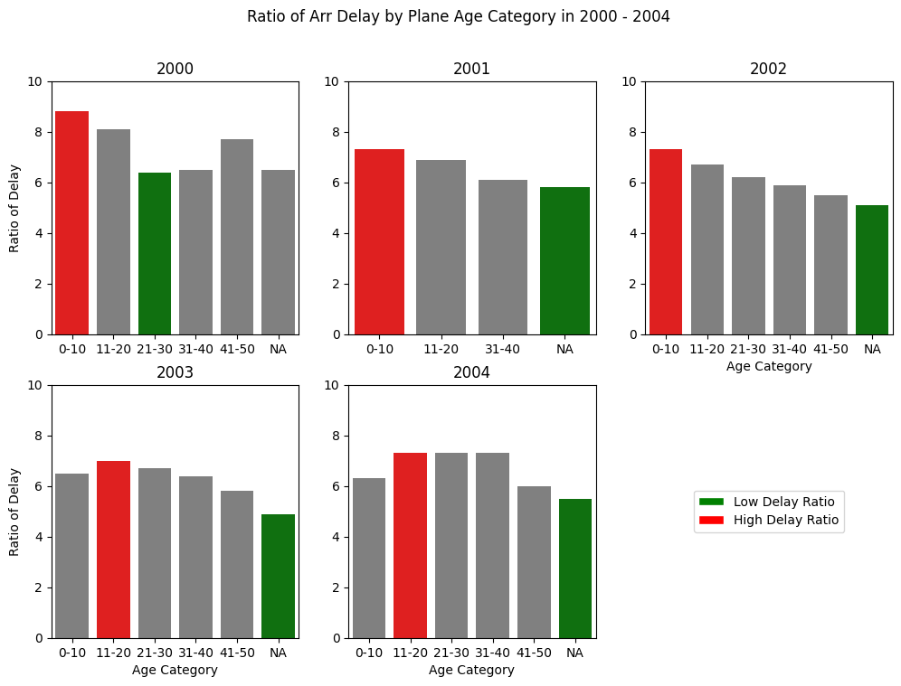

```python
fig, ax = plt.subplots(2,3, figsize= (12,8))
ax= ax.flatten()
sns.barplot(data= ratio_delay_arr[ratio_delay_arr['Year']==2000], x='Age_category', y= 'ratio_of_delay', ax=ax[0], hue= 'Age_category', palette=colours_cus_7[0])
ax[0].set_xlabel('')
ax[0].set_ylabel('Ratio of Delay')
ax[0].set_ylim(0,10)
ax[0].set_title('2000')
sns.barplot(data= ratio_delay_arr[ratio_delay_arr['Year']==2001], x='Age_category', y= 'ratio_of_delay', ax=ax[1], hue= 'Age_category', palette=colours_cus_7[1])
ax[1].set_xlabel('')
ax[1].set_ylabel('')
ax[1].set_ylim(0,10)
ax[1].set_title('2001')
sns.barplot(data= ratio_delay_arr[ratio_delay_arr['Year']==2002], x='Age_category', y= 'ratio_of_delay', ax=ax[2], hue= 'Age_category', palette=colours_cus_7[2])
ax[2].set_xlabel('Age Category')
ax[2].set_ylabel('')
ax[2].set_ylim(0,10)
ax[2].set_title('2002')
sns.barplot(data= ratio_delay_arr[ratio_delay_arr['Year']==2003], x='Age_category', y= 'ratio_of_delay', ax=ax[3], hue= 'Age_category', palette=colours_cus_7[3])
ax[3].set_xlabel('Age Category')
ax[3].set_ylabel('Ratio of Delay')
ax[3].set_ylim(0,10)
ax[3].set_title('2003')
sns.barplot(data= ratio_delay_arr[ratio_delay_arr['Year']==2004], x='Age_category', y= 'ratio_of_delay', ax=ax[4], hue= 'Age_category', palette=colours_cus_7[4])
ax[4].set_xlabel('Age Category')
ax[4].set_ylabel('')
ax[4].set_ylim(0,10)
ax[4].set_title('2004')
ax[5].axis('off')

leg_notes_7 = [Patch(facecolor = "green", edgecolor ="white", label="Low Delay Ratio"),
            Patch(facecolor = "red", edgecolor= "white", label ="High Delay Ratio")]
#this is to create manually the legend, where the color will be green and red to represents the Low Delay Ratio and High Delay Ratio respectively.
plt.legend(handles = leg_notes_7, loc = "center") #the legend will be plotted using the leg_notes_7, that is located in the center

plt.suptitle("Ratio of Arr Delay by Plane Age Category in 2000 - 2004")
plt.show()
```

For arrival delay the Na’s values seem to be low across all years except 2000, where 21-30 is the lowest. As here the ratio of delay seems low, then conclusion must be compared with departure delay ratio. Since the NA’s values having low ratio of delay, it’s possible to assume to ignore NA’s and draw a conclusion, as the NA’s values provide less impact on overall analysis. Given that conditions, then the relationship between age and Ratio of delay is weak. In 2002 and 2003, instead of upward sloping, it’s downward, means the higher the age, the lower the ratio of delay, which is an evidence to state older age is not causing higher delay.

ANSWER OF 2 C

Due to large Na's value in CancellationCode, CarrierDelay, WeatherDelay, NASDelay, SecurityDelay, LateAircraftDelay, it won't be used for prediction of diverted flights.

```python
data.isna().sum()
#to see the original data have Na's value or not. It will sum all the total Na's value in each column
```

```
Year                        0
Month                       0
DayofMonth                  0
DayOfWeek                   0
DepTime                713057
CRSDepTime                  0
ArrTime                773741
CRSArrTime                  0
UniqueCarrier               0
FlightNum                   0
TailNum                 56387
ActualElapsedTime      773742
CRSElapsedTime            270
AirTime                773862
ArrDelay               773742
DepDelay               713057
Origin                      0
Dest                        0
Distance                    0
TaxiIn                      0
TaxiOut                     0
Cancelled                   0
CancellationCode     30359138
Diverted                    0
CarrierDelay         19594928
WeatherDelay         19594928
NASDelay             19594928
SecurityDelay        19594928
LateAircraftDelay    19594928
dtype: int64
```

Choose some columns that might be useful for predictions, it will take columns that is listed below from "data" variable

```python
a = data [['Year','Month','DayofMonth','DayOfWeek','DepTime','CRSDepTime','ArrTime','CRSArrTime','UniqueCarrier','CRSElapsedTime', 'AirTime', 'Origin', 'Dest' , 'Distance','Cancelled', 'Diverted']]
```

```python
a.dtypes #to see the data types of each column in "a"
```

```
Year                 int64
Month                int64
DayofMonth           int64
DayOfWeek            int64
DepTime            float64
CRSDepTime           int64
ArrTime            float64
CRSArrTime           int64
UniqueCarrier       object
CRSElapsedTime     float64
AirTime            float64
Origin              object
Dest                object
Distance             int64
Cancelled            int64
Diverted          category
dtype: object
```

It will convert the Diverted into numeric or integer

```python
a['Diverted'] = a['Diverted'].astype(int)#The Diverted value is in category, so it will be converted to numeric
```

It will convert the UniqueCarrier, Origin, Dest into category

```python
a['UniqueCarrier'] = a['UniqueCarrier'].astype('category')#to convert the UniqueCarrier column in "a" variable into category
a['Origin'] = a['Origin'].astype('category')#to convert the Origin column in "a" variable into category
a['Dest'] = a['Dest'].astype('category')#to convert the Dest column in "a" variable into category
```

It will only stored the data from "a" variable when the 'Year' is 2000.

```python
#Use only specific Year, which is 2000 instead of all Year, due to large dataset, and make process quicker
YEAR_2000 = a [a['Year']==2000]
```

```python
#Create dummy variable for column call UniqueCarrier, and it will create n new dummy variables instead of n-1, as it will be useful for correlation purposes
dummy_YEAR_2000 = pd.get_dummies(YEAR_2000, columns = ['UniqueCarrier'], drop_first= False)
```

```python
YEAR_2000['Origin'].nunique()#since the origin have too much unique values, we drop this columns, given the dataset is too large
```

```
206
```

```python
YEAR_2000['Dest'].nunique()#since the Dest have too much unique values, we drop this columns, given the dataset is too large
```

```
206
```

```python
YEAR_2000_corr = dummy_YEAR_2000.drop(columns = ['Dest','Origin']) #it will drop the Dest and Origin due to too much unique values
YEAR_2000_corr= YEAR_2000_corr.corr()#it will then see the correlation between these variables
```

```python
YEAR_2000_corr  #to see how is the correlation of each variable
#the correlation seems small due to imbalance data between 0 and 1.
```

|  | Year | Month | DayofMonth | DayOfWeek | DepTime | CRSDepTime | ArrTime | CRSArrTime | CRSElapsedTime | AirTime | ... | UniqueCarrier_MQ | UniqueCarrier_NW | UniqueCarrier_OH | UniqueCarrier_OO | UniqueCarrier_TW | UniqueCarrier_TZ | UniqueCarrier_UA | UniqueCarrier_US | UniqueCarrier_WN | UniqueCarrier_XE |
| --- | --- | --- | --- | --- | --- | --- | --- | --- | --- | --- | --- | --- | --- | --- | --- | --- | --- | --- | --- | --- | --- |
| Year | NaN | NaN | NaN | NaN | NaN | NaN | NaN | NaN | NaN | NaN | ... | NaN | NaN | NaN | NaN | NaN | NaN | NaN | NaN | NaN | NaN |
| Month | NaN | 1.000000 | 0.001613 | 0.009287 | 0.000266 | -0.003052 | -0.003383 | -0.004064 | 0.008784 | 0.003877 | ... | NaN | 0.001350 | NaN | NaN | -0.004445 | NaN | -0.009965 | 0.004366 | 0.005446 | NaN |
| DayofMonth | NaN | 0.001613 | 1.000000 | -0.007718 | 0.001460 | -0.001084 | -0.002091 | -0.001315 | 0.000971 | 0.000433 | ... | NaN | -0.000295 | NaN | NaN | -0.000513 | NaN | 0.000095 | -0.000157 | 0.000850 | NaN |
| DayOfWeek | NaN | 0.009287 | -0.007718 | 1.000000 | 0.004671 | 0.002298 | 0.003364 | 0.005537 | 0.013590 | 0.010475 | ... | NaN | -0.002557 | NaN | NaN | -0.000690 | NaN | 0.002272 | 0.002266 | -0.009549 | NaN |
| DepTime | NaN | 0.000266 | 0.001460 | 0.004671 | 1.000000 | 0.958367 | 0.651953 | 0.729749 | -0.026102 | -0.033847 | ... | NaN | -0.005179 | NaN | NaN | 0.004162 | NaN | -0.003564 | 0.006574 | 0.015402 | NaN |
| CRSDepTime | NaN | -0.003052 | -0.001084 | 0.002298 | 0.958367 | 1.000000 | 0.627563 | 0.730889 | -0.026926 | -0.034552 | ... | NaN | -0.001833 | NaN | NaN | 0.004559 | NaN | -0.011745 | 0.010423 | 0.009027 | NaN |
| ArrTime | NaN | -0.003383 | -0.002091 | 0.003364 | 0.651953 | 0.627563 | 1.000000 | 0.856245 | 0.031354 | 0.022672 | ... | NaN | 0.001224 | NaN | NaN | -0.002274 | NaN | -0.004937 | 0.007037 | 0.003317 | NaN |
| CRSArrTime | NaN | -0.004064 | -0.001315 | 0.005537 | 0.729749 | 0.730889 | 0.856245 | 1.000000 | 0.040486 | 0.028359 | ... | NaN | -0.000088 | NaN | NaN | -0.002728 | NaN | -0.001866 | 0.005705 | -0.005527 | NaN |
| CRSElapsedTime | NaN | 0.008784 | 0.000971 | 0.013590 | -0.026102 | -0.026926 | 0.031354 | 0.040486 | 1.000000 | 0.988241 | ... | NaN | -0.002329 | NaN | NaN | 0.014864 | NaN | 0.091834 | -0.107137 | -0.254396 | NaN |
| AirTime | NaN | 0.003877 | 0.000433 | 0.010475 | -0.033847 | -0.034552 | 0.022672 | 0.028359 | 0.988241 | 1.000000 | ... | NaN | -0.016899 | NaN | NaN | 0.015660 | NaN | 0.100473 | -0.098472 | -0.218076 | NaN |
| Distance | NaN | 0.008797 | 0.000665 | 0.013445 | -0.030289 | -0.029906 | 0.018399 | 0.027459 | 0.984880 | 0.983289 | ... | NaN | -0.021323 | NaN | NaN | 0.011517 | NaN | 0.109466 | -0.115531 | -0.208805 | NaN |
| Cancelled | NaN | -0.002795 | 0.014195 | -0.016047 | NaN | 0.010560 | NaN | 0.012034 | -0.010860 | NaN | ... | NaN | -0.009484 | NaN | NaN | -0.016566 | NaN | 0.053175 | 0.009779 | -0.056476 | NaN |
| Diverted | NaN | -0.001281 | 0.000886 | 0.003978 | 0.008581 | 0.005866 | NaN | 0.008273 | 0.016167 | NaN | ... | NaN | 0.000763 | NaN | NaN | -0.001862 | NaN | -0.002455 | 0.005953 | -0.004090 | NaN |
| UniqueCarrier_AA | NaN | 0.001249 | -0.000268 | 0.002115 | -0.021034 | -0.025033 | 0.006347 | 0.006747 | 0.185460 | 0.164649 | ... | NaN | -0.127045 | NaN | NaN | -0.086081 | NaN | -0.154200 | -0.150972 | -0.169429 | NaN |
| UniqueCarrier_AQ | NaN | 0.063784 | -0.000042 | 0.002803 | -0.006814 | -0.006214 | -0.011696 | -0.013783 | -0.055714 | -0.050365 | ... | NaN | -0.014458 | NaN | NaN | -0.009796 | NaN | -0.017548 | -0.017181 | -0.019282 | NaN |
| UniqueCarrier_AS | NaN | -0.000117 | -0.000085 | -0.000497 | 0.001462 | 0.002483 | -0.008070 | -0.009110 | -0.013414 | 0.000212 | ... | NaN | -0.054734 | NaN | NaN | -0.037086 | NaN | -0.066433 | -0.065042 | -0.072994 | NaN |
| UniqueCarrier_B6 | NaN | NaN | NaN | NaN | NaN | NaN | NaN | NaN | NaN | NaN | ... | NaN | NaN | NaN | NaN | NaN | NaN | NaN | NaN | NaN | NaN |
| UniqueCarrier_CO | NaN | -0.003118 | -0.000088 | -0.009268 | -0.016370 | -0.015438 | 0.008627 | 0.013669 | 0.123699 | 0.110826 | ... | NaN | -0.089344 | NaN | NaN | -0.060536 | NaN | -0.108440 | -0.106170 | -0.119150 | NaN |
| UniqueCarrier_DH | NaN | NaN | NaN | NaN | NaN | NaN | NaN | NaN | NaN | NaN | ... | NaN | NaN | NaN | NaN | NaN | NaN | NaN | NaN | NaN | NaN |
| UniqueCarrier_DL | NaN | -0.005618 | -0.000117 | 0.011658 | 0.009776 | 0.016186 | 0.000378 | 0.004084 | 0.000420 | -0.019877 | ... | NaN | -0.142935 | NaN | NaN | -0.096848 | NaN | -0.173486 | -0.169854 | -0.190620 | NaN |
| UniqueCarrier_EV | NaN | NaN | NaN | NaN | NaN | NaN | NaN | NaN | NaN | NaN | ... | NaN | NaN | NaN | NaN | NaN | NaN | NaN | NaN | NaN | NaN |
| UniqueCarrier_FL | NaN | NaN | NaN | NaN | NaN | NaN | NaN | NaN | NaN | NaN | ... | NaN | NaN | NaN | NaN | NaN | NaN | NaN | NaN | NaN | NaN |
| UniqueCarrier_HA | NaN | NaN | NaN | NaN | NaN | NaN | NaN | NaN | NaN | NaN | ... | NaN | NaN | NaN | NaN | NaN | NaN | NaN | NaN | NaN | NaN |
| UniqueCarrier_HP | NaN | 0.000667 | 0.000392 | 0.000962 | 0.008729 | 0.015922 | -0.023256 | -0.019776 | 0.032201 | 0.038846 | ... | NaN | -0.065646 | NaN | NaN | -0.044479 | NaN | -0.079677 | -0.078009 | -0.087546 | NaN |
| UniqueCarrier_MQ | NaN | NaN | NaN | NaN | NaN | NaN | NaN | NaN | NaN | NaN | ... | NaN | NaN | NaN | NaN | NaN | NaN | NaN | NaN | NaN | NaN |
| UniqueCarrier_NW | NaN | 0.001350 | -0.000295 | -0.002557 | -0.005179 | -0.001833 | 0.001224 | -0.000088 | -0.002329 | -0.016899 | ... | NaN | 1.000000 | NaN | NaN | -0.072795 | NaN | -0.130401 | -0.127671 | -0.143279 | NaN |
| UniqueCarrier_OH | NaN | NaN | NaN | NaN | NaN | NaN | NaN | NaN | NaN | NaN | ... | NaN | NaN | NaN | NaN | NaN | NaN | NaN | NaN | NaN | NaN |
| UniqueCarrier_OO | NaN | NaN | NaN | NaN | NaN | NaN | NaN | NaN | NaN | NaN | ... | NaN | NaN | NaN | NaN | NaN | NaN | NaN | NaN | NaN | NaN |
| UniqueCarrier_TW | NaN | -0.004445 | -0.000513 | -0.000690 | 0.004162 | 0.004559 | -0.002274 | -0.002728 | 0.014864 | 0.015660 | ... | NaN | -0.072795 | NaN | NaN | 1.000000 | NaN | -0.088354 | -0.086505 | -0.097080 | NaN |
| UniqueCarrier_TZ | NaN | NaN | NaN | NaN | NaN | NaN | NaN | NaN | NaN | NaN | ... | NaN | NaN | NaN | NaN | NaN | NaN | NaN | NaN | NaN | NaN |
| UniqueCarrier_UA | NaN | -0.009965 | 0.000095 | 0.002272 | -0.003564 | -0.011745 | -0.004937 | -0.001866 | 0.091834 | 0.100473 | ... | NaN | -0.130401 | NaN | NaN | -0.088354 | NaN | 1.000000 | -0.154959 | -0.173903 | NaN |
| UniqueCarrier_US | NaN | 0.004366 | -0.000157 | 0.002266 | 0.006574 | 0.010423 | 0.007037 | 0.005705 | -0.107137 | -0.098472 | ... | NaN | -0.127671 | NaN | NaN | -0.086505 | NaN | -0.154959 | 1.000000 | -0.170262 | NaN |
| UniqueCarrier_WN | NaN | 0.005446 | 0.000850 | -0.009549 | 0.015402 | 0.009027 | 0.003317 | -0.005527 | -0.254396 | -0.218076 | ... | NaN | -0.143279 | NaN | NaN | -0.097080 | NaN | -0.173903 | -0.170262 | 1.000000 | NaN |
| UniqueCarrier_XE | NaN | NaN | NaN | NaN | NaN | NaN | NaN | NaN | NaN | NaN | ... | NaN | NaN | NaN | NaN | NaN | NaN | NaN | NaN | NaN | NaN |

34 rows × 34 columns

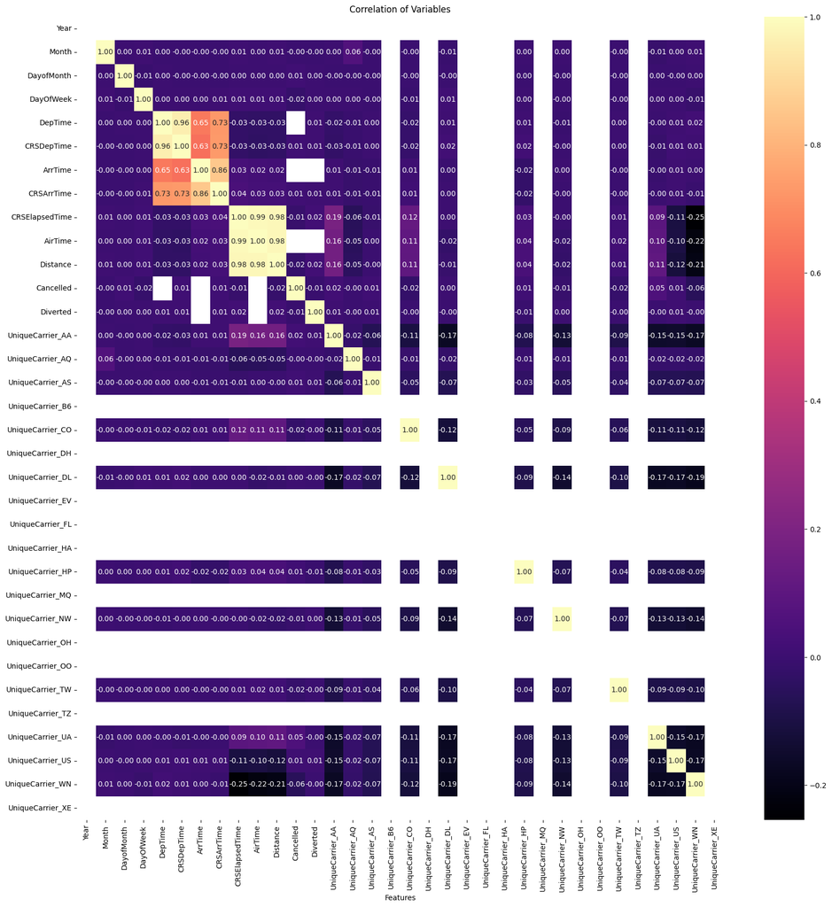

```python
plt.figure(figsize = (20,20)) #it will plot the figure later in 20 inches width and height
sns.heatmap(YEAR_2000_corr, annot= True,cmap='magma', fmt= ".2f") #it will plot heatmap, using YEAR_2000_corr data, with annot True, which mean it will show the correlation result on the graph, with two decimal point
plt.title('Correlation of Variables')
plt.xlabel('Features')
plt.show()#it will show the plot
```

1. DepTime with CRSDepTime
2. DepTime with ArrTime
3. DepTime with CRSArrTime
4. ArrTime with CRSDepTime
5. ArrTime with CRSArrTime
6. CRSElapsedTime with AirTime
7. CRSElapsedTime with Distance

These all have high correlation between each other. It suggest there's strong linear relationship between them. Therefore, to avoid multicolinearity, we only choose one of the variable, instead of all variables.

Here as DepTime, CRSDepTime, CRSArrTime, and CRSArrTime is highly correlated between each other, CRSDepTime will be used. This due to the ArrTime which is the actual arrival time unlikely to be predictor, since the diverted flights mean it's not landed in the scheduled destination. Then ArrTime won't be useful. While CRSDepTime and DepTime might be useful, the fact it has high correlation, then one of it will be selected, which is CRSDepTime.

CRSElapsedTime might be useful to predict diverted flights, however it's highly correlated with AirTime and Distance, therefore instead of choosing all variables, it will choose Distance to avoid multicolinearity. It also because of the no NA's value in Distance, unlike CRSElapsedTime have NA's values

```python
relation_non_linear= YEAR_2000_corr.corr(method= 'spearman')#to see the correlation instead of one unit increase will influence the diverted, it will see whether any certain cases will predict diverted better.
#For example, month, instead of one month increase, that have quite low relationship with Diverted, is it possible that in certain Month, it has high correlation with Diverted, especially Month will have seasonality and non linear relationship
```

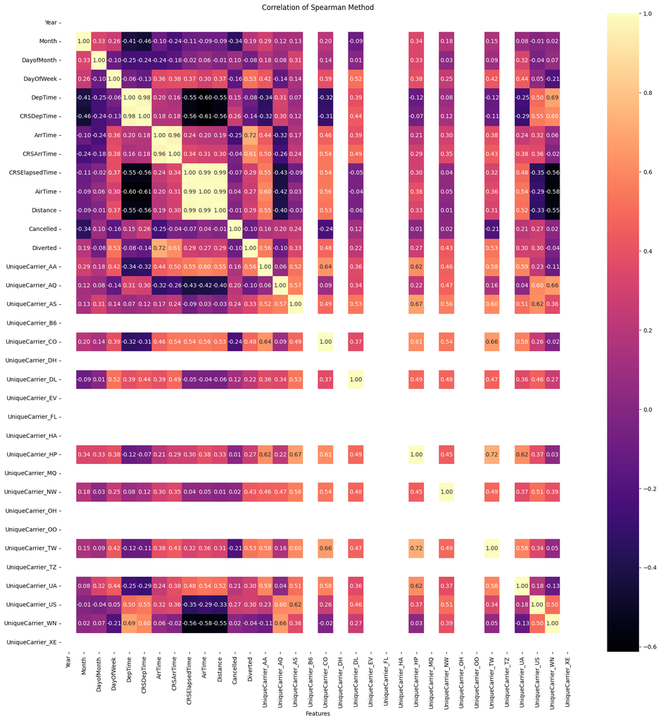

```python
plt.figure(figsize = (20,20))
sns.heatmap(relation_non_linear, annot= True,cmap= 'magma', fmt= ".2f")#to plot the heatmap using relation_non_linear data, with showing the correlation by 2 decimal points
plt.title('Correlation of Spearman Method')#plot the title
plt.xlabel('Features')
plt.show()
```

It seems the relation between Diverted (target variable) with other variables seems small, it mean it might not be a linear relationship or monotonic between them. Therefore spearman method will be use to check any monotonic relationship. For example, Distance and Diverted only have 0.02 correlation, but it might because one unit increase on distance( additional one miles) it not neccessary will make Diverted happens. As here it should be noted there's high imbalance data between 0 (Not Diverted) and 1 (Diverted). To check the real relationship, it will use spearman method, so that we can see whether there's monotonic relationship between Diverted and other variables.

Besides the given variables that mentioned before, which is CRSArrTime, ArrTime, CRSDepTime, DepTime, CRSElapsedTime, Distance, and Airtime. Here the DayOfWeek have correlation 0.53, CRSArrTime 0.61, ArrTime, and certain unique carrier have high relationship with Diverted. This is a strong evidence that indicates DayOfWeek, CRSArrTime might be useful for predictions.

Therefore DayOfWeek must be included in analysis. CRSArrTime and ArrTime is highly correlated with CRSDepTime therefore it's logical to use one of this variable. Distance will be used since it shows there's relationship between them as well DayOfMonth, even though it's not that high, the fact that it might have any seasonality on certain day of month, or distance might be a good predictor, as the correlation is highly affected by imbalance data.

CRSDepTime have higher correlation with Diverted rather than DepTime then CRSDepTime will be chosen. As well as Unique Carrier, certain UniqueCarrier have quite high correlation such as AA, CO, TW.

Since the correlation shows it's not linear relationship for DayOfWeek or DayofMonth, which means it's not increase or decreasing per unit and it should convert it into categorical.

In conclusion, the DayOfWeek and CRSArrTime have high non-linear relationship with Diverted. CRSDepTime will be also selected since it shows the scheduled departure time that by logical should be useful to predict diversion. Distance and DayofMonth have weak monotonic relationship with Diverted, but it might be useful as the data used here is highly imbalance. Certain UniqueCarrier have strong monotonic relation with Diverted, therefore this feature should be selected. CRSArrTime and CRSDepTime should be chosen over ArrTime and DepTime, as the actual arrival and departure time have NA's value, while CRSArrTime and CRSDepTime don't have.

The reason why CRSDepTime or CRSArrTime or Distance is not converted to categorical as the dataset is large. In addition, these features could be seen as numeric, rather than categorical. Even though it's possible to create categorical, by certain time for example, from 00:00 to 04:00, etc, the fact that CRSArrTime have a specific pattern rather than linear trend enables to treat it as numeric as logistic regression could capture this.

Here, it will use UniqueCarrier, Diverted, CRSDepTime, Distance, DayOfWeek, DayofMonth, CRSArrTime columns

```python
a['DayofMonth'] = a['DayofMonth'].astype('category')#to convert the DayofMonth column in "a" variable into category
a['DayOfWeek'] = a['DayOfWeek'].astype('category')#to convert the DayOfWeek column in "a" variable into category
#this have been done based on the previous argument
```

1. Create a function, for i that is within 2000 to 2004, then the datasets will contain, "a" when the Year is equals to i which is 2000 to 2004. It means it will iterates later, and when the Year is equals to 2000 then Year is equals to 2001, etc.
2. Then the Year_nums will be the datasets and drop some columns that are not used for training model.
3. Then it will add the Year_nums as list into Year_num
4. Therefore Year_num will be a list of list
5. Year_targets will be datasets that only contains Diverted column
6. It will add the Year_targets as a list into Year_target. So the Year_target is also a list of list

```python
dataset=[]#create empty list call dataset
Year_num=[]#create empty list call Year_num
Year_target=[] #create empty list call Year_target

for i in range (2000,2005):
    datasets = a[a['Year'] ==i]
    Year_nums = datasets.drop(columns= ['Dest','Origin','Year','DepTime','ArrTime','CRSElapsedTime','AirTime','Cancelled','Diverted'])
    Year_num.append([Year_nums])
    Year_targets= datasets[['Diverted']]
    Year_target.append([Year_targets])
```

Since the Year_num is a list of list, to convert it into data frame for each index, here it will done manually. First, it will convert a list into array, then it will use squeeze() because the shape is (1, 5million+, 7) which is rows are around 5 million and col is 7, while dataframe should have 2 not 3 dimensions. Therefore it force to delete the unwanted dimension.

Year_2000 will have columns like 0,1,2,3 etc which is an index, therefore the columns name must be changed. It will rename the columns based on this order,Month ,DayofMonth ,DayOfWeek,CRSDepTime, CRSArrTime, UniqueCarrier, Distance.

```python
Year_2000= pd.DataFrame(np.array(Year_num[0]).squeeze())
Year_2000.columns = ['Month','DayofMonth','DayOfWeek','CRSDepTime','CRSArrTime','UniqueCarrier','Distance']
Year_2001= pd.DataFrame(np.array(Year_num[1]).squeeze())
Year_2001.columns = ['Month','DayofMonth','DayOfWeek','CRSDepTime','CRSArrTime','UniqueCarrier','Distance']
Year_2002= pd.DataFrame(np.array(Year_num[2]).squeeze())
Year_2002.columns = ['Month','DayofMonth','DayOfWeek','CRSDepTime','CRSArrTime','UniqueCarrier','Distance']
Year_2003= pd.DataFrame(np.array(Year_num[3]).squeeze())
Year_2003.columns = ['Month','DayofMonth','DayOfWeek','CRSDepTime','CRSArrTime','UniqueCarrier','Distance']
Year_2004= pd.DataFrame(np.array(Year_num[4]).squeeze())
Year_2004.columns = ['Month','DayofMonth','DayOfWeek','CRSDepTime','CRSArrTime','UniqueCarrier','Distance']
```

Since the Year_target is a list of list, to convert it into data frame for each index, here it will done manually. First, it will convert a list into array, then it will use squeeze() because the shape is (1, 5million+, 1) which is rows are around 5 million and column is 1, while dataframe should have 2 not 3 dimensions. Therefore it force to delete the unwanted dimension.

```python
Year_2000_target= pd.DataFrame(np.array(Year_target[0]).squeeze())
Year_2000_target.columns = ['Diverted']
Year_2001_target= pd.DataFrame(np.array(Year_target[1]).squeeze())
Year_2001_target.columns = ['Diverted']
Year_2002_target= pd.DataFrame(np.array(Year_target[2]).squeeze())
Year_2002_target.columns = ['Diverted']
Year_2003_target= pd.DataFrame(np.array(Year_target[3]).squeeze())
Year_2003_target.columns = ['Diverted']
Year_2004_target= pd.DataFrame(np.array(Year_target[4]).squeeze())
Year_2004_target.columns = ['Diverted']
```

The features chosen here are not contains NA's values which is shown previously.

```python
YEAR_NUM = ['Month','CRSDepTime','CRSArrTime','Distance'] #it is the name of numerical variable
```

```python
YEAR_CAT = ['UniqueCarrier','DayofMonth','DayOfWeek'] # it contains name of the categorical variable
```

```python
trans_numer = Pipeline(steps = [
    ('Scaler_num',StandardScaler())])

#it will use Standard_Scaler to convert it into the same unit or measure (same scale). It will convert it into standard normal. The formula is (x-m)/sd, where m is mean, sd is standard deviation
#Therefore it will be standardized
#it then will be used for numerical variables
#this step call Scaler_num (it's a label)
```

```python
trans_cate = Pipeline(steps= [
    ('Hot_encoder_cat', OneHotEncoder (handle_unknown ='ignore')) ])
#it will use OneHotEncoder to convert the categorical variables so that it can be used of logistic regression to train the model.
#it will be done through creating sparse matrix
#when certain things are not available during model training, then it won't raise error, this because it will be used repeatedly for 5 times that represents each model year.
#the stage is call Hot_encoder_cat , it will be useful for categorical variable
```

```python
trans_combs = ColumnTransformer ( transformers = [
    ('Num', trans_numer, YEAR_NUM),
    ('Cate', trans_cate, YEAR_CAT)])

#ColumnTransformer must be used since there's 2 different types of data, which is numeric and category.
# it will use the trans_numer that created before, it will be applied in columns that is in YEAR_NUM (numerical features). The step is call Num
# it will use the trans_cate that created before, it will be applied in columns that is in YEAR_CAT (categorical features). This step is call Cate
```

1. It will split the data from Year_2000 and Year_2000_target into train and test data. Year_2000 contains the features excluding the target variable. Where the Year_2000_target include only target variable which is Diverted. It will split 50% of train data, and 50% of test data. The train_x_2000 is contains the training data, train_y_2000 also the training data. Then text_x_2000 contain the test data which is not used when training the model. This will be used to predict and comparing with the actual data. test_y_2000 is the actual data of the test_x_2000, which is not seen during the training neither on prediction of test_x_2000.

train_y_2000 will contains only dependent variable or target, which is Diverted, while train_x_2000 contains other variables or features except Diverted. test_x_2000 will be used for prediction later that will give back 0 or 1 as result so that it can be compared with test_y_2000

```python
#1
train_x_2000, test_x_2000, train_y_2000,test_y_2000 = train_test_split(Year_2000, Year_2000_target, test_size= 0.5, random_state= 1)
```

```python
#2
log_reg = Pipeline (steps =[
    ('trans', trans_combs),
    ('log_reg', LogisticRegression(max_iter=500, solver='saga',penalty= None))])
```

```python
#3
log_reg.fit(train_x_2000, train_y_2000)
```

```
Pipeline(steps=[('trans',
                 ColumnTransformer(transformers=[('Num',
                                                  Pipeline(steps=[('Scaler_num',
                                                                   StandardScaler())]),
                                                  ['Month', 'CRSDepTime',
                                                   'CRSArrTime', 'Distance']),
                                                 ('Cate',
                                                  Pipeline(steps=[('Hot_encoder_cat',
                                                                   OneHotEncoder(handle_unknown='ignore'))]),
                                                  ['UniqueCarrier',
                                                   'DayofMonth',
                                                   'DayOfWeek'])])),
                ('log_reg',
                 LogisticRegression(max_iter=500, penalty=None,
                                    solver='saga'))])
```

```python
#4
coef_num_2000=log_reg.named_steps['log_reg'].coef_
features_name_2000 =log_reg.named_steps['trans'].get_feature_names_out()
```

```python
#5
YEAR_2000_COEFF = pd.DataFrame({
    'Selected_Feature' : features_name_2000,
    'Coefficient' : coef_num_2000.flatten()})
```

```python
#6
YEAR_2000_COEFF
```

|  | Selected_Feature | Coefficient |
| --- | --- | --- |
| 0 | Num__Month | -0.038537 |
| 1 | Num__CRSDepTime | 0.015418 |
| 2 | Num__CRSArrTime | 0.153444 |
| 3 | Num__Distance | 0.274365 |
| 4 | Cate__UniqueCarrier_AA | -1.457467 |
| 5 | Cate__UniqueCarrier_AQ | -6.710341 |
| 6 | Cate__UniqueCarrier_AS | -1.135048 |
| 7 | Cate__UniqueCarrier_CO | -1.999466 |
| 8 | Cate__UniqueCarrier_DL | -1.888560 |
| 9 | Cate__UniqueCarrier_HP | -2.477477 |
| 10 | Cate__UniqueCarrier_NW | -1.599074 |
| 11 | Cate__UniqueCarrier_TW | -1.903650 |
| 12 | Cate__UniqueCarrier_UA | -1.923474 |
| 13 | Cate__UniqueCarrier_US | -1.336874 |
| 14 | Cate__UniqueCarrier_WN | -1.726875 |
| 15 | Cate__DayofMonth_1 | -0.684451 |
| 16 | Cate__DayofMonth_2 | -0.850756 |
| 17 | Cate__DayofMonth_3 | -0.659902 |
| 18 | Cate__DayofMonth_4 | -0.850751 |
| 19 | Cate__DayofMonth_5 | -1.044957 |
| 20 | Cate__DayofMonth_6 | -1.239077 |
| 21 | Cate__DayofMonth_7 | -0.968492 |
| 22 | Cate__DayofMonth_8 | -0.967840 |
| 23 | Cate__DayofMonth_9 | -0.796879 |
| 24 | Cate__DayofMonth_10 | -0.998907 |
| 25 | Cate__DayofMonth_11 | -0.174949 |
| 26 | Cate__DayofMonth_12 | -0.615587 |
| 27 | Cate__DayofMonth_13 | -0.779649 |
| 28 | Cate__DayofMonth_14 | -0.605295 |
| 29 | Cate__DayofMonth_15 | -0.752316 |
| 30 | Cate__DayofMonth_16 | -0.821766 |
| 31 | Cate__DayofMonth_17 | -0.768105 |
| 32 | Cate__DayofMonth_18 | -0.377283 |
| 33 | Cate__DayofMonth_19 | -0.494235 |
| 34 | Cate__DayofMonth_20 | -0.836566 |
| 35 | Cate__DayofMonth_21 | -0.787141 |
| 36 | Cate__DayofMonth_22 | -0.724751 |
| 37 | Cate__DayofMonth_23 | -1.071887 |
| 38 | Cate__DayofMonth_24 | -0.929672 |
| 39 | Cate__DayofMonth_25 | -0.448554 |
| 40 | Cate__DayofMonth_26 | -0.783614 |
| 41 | Cate__DayofMonth_27 | -0.761170 |
| 42 | Cate__DayofMonth_28 | -0.762834 |
| 43 | Cate__DayofMonth_29 | -1.198393 |
| 44 | Cate__DayofMonth_30 | -0.788090 |
| 45 | Cate__DayofMonth_31 | -0.614437 |
| 46 | Cate__DayOfWeek_1 | -3.522945 |
| 47 | Cate__DayOfWeek_2 | -3.617223 |
| 48 | Cate__DayOfWeek_3 | -3.585529 |
| 49 | Cate__DayOfWeek_4 | -3.340025 |
| 50 | Cate__DayOfWeek_5 | -3.243603 |
| 51 | Cate__DayOfWeek_6 | -3.554646 |
| 52 | Cate__DayOfWeek_7 | -3.294335 |

1. It will predict the test_x_2000 using the log_reg which have been trained on the train dataset. Then it will return as array of 0 and 1.
2. It shows the accuracy score by comparing the prediction ( the one that predict the test_x_2000) and the test_y_2000 (actual or true or original data). It seems there's high accuracy, however, it should be seen with cautious since the data is highly imbalance.
3. The confusion matrix will be created, to see how many true postive or negative, false positive or negative
4. probabi_y_2000 will store the prediction of test_x_2000 in a probability. It will select all rows and the column index 1 (second col). This have been done so that it could adjust the threshold. Here it will be set as 0.005 due to high imbalance data. It will be stored as integer in predict_y_1_2000
5. It will shows the adjusted threshold confusion matrix, it indicates better sensitivity than previously.

```python
#1
prediction_y_2000 = log_reg.predict(test_x_2000)
```

```python
#2
accuracy_score(test_y_2000,prediction_y_2000)
```

```
0.9974615734373526
```

```python
#3
confusion_matrix(test_y_2000, prediction_y_2000)
```

```
array([[2834311,       0],
       [   7213,       0]], dtype=int64)
```

```python
#4
probabi_y_2000 = log_reg.predict_proba(test_x_2000)[:,1]
predict_y_1_2000= (probabi_y_2000 >= 0.005).astype(int)
```

```python
#5
confusion_matrix(test_y_2000, predict_y_1_2000)
```

```
array([[2688423,  145888],
       [   6342,     871]], dtype=int64)
```

1. It will split the data from Year_2001 and Year_2001_target into train and test data. Year_2001 contains the features excluding the target variable. Where the Year_2001_target include only target variable which is Diverted. It will split 50% of train data, and 50% of test data. The train_x_2001 is contains the training data, train_y_2001 also the training data. Then text_x_2001 contain the test data which is not used when training the model. This will be used to predict and comparing with the actual data. test_y_2001 is the actual data of the test_x_2001, which is not seen during the training neither on prediction of test_x_2001.

train_y_2001 will contains only dependent variable or target, which is Diverted, while train_x_2001 contains other variables or features except Diverted. test_x_2001 will be used for prediction later that will give back 0 or 1 as result so that it can be compared with test_y_2001

2. it will use the trans_combs that created before and the step call trans, then it will use the LogisticRegression with saga as solver due to high imbalance, and penalty will be set to None as the model is used only for coefficient purposes. The maximum iterations will be 500. If the algorithm is not converging then it will stop at 500 iterations. This is being set so that it won't takes too much time due to large dataset.
3. It will train using log_reg on train_x_2001 and train_y_2001.
4. coef_num_2001 will stored the log_reg when the step name is log_reg and take the coefficient. The features_name_2001 will take when the step is call trans and get the name of features selected.
5. It will convert the coef_num_2001 and features_name_2001 into a dataframe. The flatten will convert into 1D to include it into the dataframe, since it's an array for coef_num_2001. The coef_num_2001 will be stored as Coefficient, while the features_name_2001 is stored as Selected_Feature.
6. It will print out the YEAR_2001_COEFF that contains Selected_Feature and Coefficient.

```python
#1
train_x_2001, test_x_2001, train_y_2001,test_y_2001 = train_test_split(Year_2001, Year_2001_target, test_size= 0.5, random_state= 2)
```

```python
#2
log_reg_2001 = Pipeline (steps =[
    ('trans', trans_combs),
    ('log_reg', LogisticRegression(max_iter=500, solver='saga',penalty= None))])
```

```python
#3
log_reg_2001.fit(train_x_2001, train_y_2001)
```

```
Pipeline(steps=[('trans',
                 ColumnTransformer(transformers=[('Num',
                                                  Pipeline(steps=[('Scaler_num',
                                                                   StandardScaler())]),
                                                  ['Month', 'CRSDepTime',
                                                   'CRSArrTime', 'Distance']),
                                                 ('Cate',
                                                  Pipeline(steps=[('Hot_encoder_cat',
                                                                   OneHotEncoder(handle_unknown='ignore'))]),
                                                  ['UniqueCarrier',
                                                   'DayofMonth',
                                                   'DayOfWeek'])])),
                ('log_reg',
                 LogisticRegression(max_iter=500, penalty=None,
                                    solver='saga'))])
```

```python
#4
coef_num_2001=log_reg_2001.named_steps['log_reg'].coef_
features_name_2001 =log_reg_2001.named_steps['trans'].get_feature_names_out()
```

```python
#5
YEAR_2001_COEFF = pd.DataFrame({
    'Selected_Feature' : features_name_2001,
    'Coefficient' : coef_num_2001.flatten()})
```

```python
#6
YEAR_2001_COEFF
```

|  | Selected_Feature | Coefficient |
| --- | --- | --- |
| 0 | Num__Month | -0.052275 |
| 1 | Num__CRSDepTime | -0.071277 |
| 2 | Num__CRSArrTime | 0.082361 |
| 3 | Num__Distance | 0.275938 |
| 4 | Cate__UniqueCarrier_AA | -1.675091 |
| 5 | Cate__UniqueCarrier_AQ | -5.531167 |
| 6 | Cate__UniqueCarrier_AS | -1.441840 |
| 7 | Cate__UniqueCarrier_CO | -1.767961 |
| 8 | Cate__UniqueCarrier_DL | -1.771688 |
| 9 | Cate__UniqueCarrier_HP | -2.123219 |
| 10 | Cate__UniqueCarrier_MQ | -1.723009 |
| 11 | Cate__UniqueCarrier_NW | -1.527296 |
| 12 | Cate__UniqueCarrier_TW | -1.928428 |
| 13 | Cate__UniqueCarrier_UA | -1.810909 |
| 14 | Cate__UniqueCarrier_US | -1.593546 |
| 15 | Cate__UniqueCarrier_WN | -1.813458 |
| 16 | Cate__DayofMonth_1 | -0.860486 |
| 17 | Cate__DayofMonth_2 | -1.222304 |
| 18 | Cate__DayofMonth_3 | -0.868624 |
| 19 | Cate__DayofMonth_4 | -0.752023 |
| 20 | Cate__DayofMonth_5 | -0.354627 |
| 21 | Cate__DayofMonth_6 | -0.837279 |
| 22 | Cate__DayofMonth_7 | -0.939683 |
| 23 | Cate__DayofMonth_8 | -0.883321 |
| 24 | Cate__DayofMonth_9 | -0.789004 |
| 25 | Cate__DayofMonth_10 | -0.523330 |
| 26 | Cate__DayofMonth_11 | 0.174953 |
| 27 | Cate__DayofMonth_12 | -0.539435 |
| 28 | Cate__DayofMonth_13 | -0.749501 |
| 29 | Cate__DayofMonth_14 | -0.413170 |
| 30 | Cate__DayofMonth_15 | -0.757183 |
| 31 | Cate__DayofMonth_16 | -0.884523 |
| 32 | Cate__DayofMonth_17 | -1.223068 |
| 33 | Cate__DayofMonth_18 | -1.024078 |
| 34 | Cate__DayofMonth_19 | -1.061919 |
| 35 | Cate__DayofMonth_20 | -0.782242 |
| 36 | Cate__DayofMonth_21 | -0.912579 |
| 37 | Cate__DayofMonth_22 | -0.442095 |
| 38 | Cate__DayofMonth_23 | -0.670754 |
| 39 | Cate__DayofMonth_24 | -0.971225 |
| 40 | Cate__DayofMonth_25 | -0.870336 |
| 41 | Cate__DayofMonth_26 | -1.206267 |
| 42 | Cate__DayofMonth_27 | -1.109544 |
| 43 | Cate__DayofMonth_28 | -0.831649 |
| 44 | Cate__DayofMonth_29 | -0.873510 |
| 45 | Cate__DayofMonth_30 | -0.431218 |
| 46 | Cate__DayofMonth_31 | -1.097588 |
| 47 | Cate__DayOfWeek_1 | -3.581704 |
| 48 | Cate__DayOfWeek_2 | -3.362906 |
| 49 | Cate__DayOfWeek_3 | -3.688370 |
| 50 | Cate__DayOfWeek_4 | -3.388911 |
| 51 | Cate__DayOfWeek_5 | -3.505979 |
| 52 | Cate__DayOfWeek_6 | -3.499462 |
| 53 | Cate__DayOfWeek_7 | -3.680280 |

1. It will predict the test_x_2001 using the log_reg which have been trained on the train dataset. Then it will return as array of 0 and 1.
2. It shows the accuracy score by comparing the prediction ( the one that predict the test_x_2001) and the test_y_2001 (actual or true or original data). It seems there's high accuracy, however, it should be seen with cautious since the data is highly imbalance.
3. The confusion matrix will be created, to see how many true postive or negative, false positive or negative
4. probabi_y_2001 will store the prediction of test_x_2001 in a probability. It will select all rows and the column index 1 (second col). This have been done so that it could adjust the threshold. Here it will be set as 0.005 due to high imbalance data. It will be stored as integer in predict_y_1_2001
5. It will shows the adjusted threshold confusion matrix, it indicates better sensitivity than previously.

```python
#1
prediction_y_2001 = log_reg_2001.predict(test_x_2001)
```

```python
#2
accuracy_score(test_y_2001,prediction_y_2001)
```

```
0.9978507920868397
```

```python
#3
confusion_matrix(test_y_2001, prediction_y_2001)
```

```
array([[2977477,       0],
       [   6413,       0]], dtype=int64)
```

```python
#4
probabi_y_2001 = log_reg_2001.predict_proba(test_x_2001)[:,1]
```

```python
#4
predict_y_1_2001= (probabi_y_2001 >= 0.005).astype(int)
```

```python
#5
confusion_matrix(test_y_2001, predict_y_1_2001)
```

```
array([[2879216,   98261],
       [   5787,     626]], dtype=int64)
```

1. It will split the data from Year_2002 and Year_2002_target into train and test data. Year_2002 contains the features excluding the target variable. Where the Year_2002_target include only target variable which is Diverted. It will split 50% of train data, and 50% of test data. The train_x_2002 is contains the training data, train_y_2002 also the training data. Then text_x_2002 contain the test data which is not used when training the model. This will be used to predict and comparing with the actual data. test_y_2002 is the actual data of the test_x_2002, which is not seen during the training neither on prediction of test_x_2002.

train_y_2002 will contains only dependent variable or target, which is Diverted, while train_x_2002 contains other variables or features except Diverted. test_x_2002 will be used for prediction later that will give back 0 or 1 as result so that it can be compared with test_y_2002

2. it will use the trans_combs that created before and the step call trans, then it will use the LogisticRegression with saga as solver due to high imbalance, and penalty will be set to None as the model is used only for coefficient purposes. The maximum iterations will be 500. If the algorithm is not converging then it will stop at 500 iterations. This is being set so that it won't takes too much time due to large dataset.
3. It will train using log_reg on train_x_2002 and train_y_2002.
4. coef_num_2002 will stored the log_reg when the step name is log_reg and take the coefficient. The features_name_2002 will take when the step is call trans and get the name of features selected.
5. It will convert the coef_num_2002 and features_name_2002 into a dataframe. The flatten will convert into 1D to include it into the dataframe, since it's an array for coef_num_2002. The coef_num_2002 will be stored as Coefficient, while the features_name_2002 is stored as Selected_Feature.
6. It will print out the YEAR_2002_COEFF that contains Selected_Feature and Coefficient.

```python
#1
train_x_2002, test_x_2002, train_y_2002,test_y_2002 = train_test_split(Year_2002, Year_2002_target, test_size= 0.5, random_state= 3)
```

```python
#2
log_reg_2002 = Pipeline (steps =[
    ('trans', trans_combs),
    ('log_reg', LogisticRegression(max_iter=500, solver='saga',penalty= None))])
```

```python
#3
log_reg_2002.fit(train_x_2002, train_y_2002)
```

```
Pipeline(steps=[('trans',
                 ColumnTransformer(transformers=[('Num',
                                                  Pipeline(steps=[('Scaler_num',
                                                                   StandardScaler())]),
                                                  ['Month', 'CRSDepTime',
                                                   'CRSArrTime', 'Distance']),
                                                 ('Cate',
                                                  Pipeline(steps=[('Hot_encoder_cat',
                                                                   OneHotEncoder(handle_unknown='ignore'))]),
                                                  ['UniqueCarrier',
                                                   'DayofMonth',
                                                   'DayOfWeek'])])),
                ('log_reg',
                 LogisticRegression(max_iter=500, penalty=None,
                                    solver='saga'))])
```

```python
#4
coef_num_2002=log_reg_2002.named_steps['log_reg'].coef_
features_name_2002 =log_reg_2002.named_steps['trans'].get_feature_names_out()
```

```python
#5
YEAR_2002_COEFF = pd.DataFrame({
    'Selected_Feature' : features_name_2002,
    'Coefficient' : coef_num_2002.flatten()})
```

```python
#6
YEAR_2002_COEFF
```

|  | Selected_Feature | Coefficient |
| --- | --- | --- |
| 0 | Num__Month | 0.065857 |
| 1 | Num__CRSDepTime | -0.101607 |
| 2 | Num__CRSArrTime | 0.241036 |
| 3 | Num__Distance | 0.266627 |
| 4 | Cate__UniqueCarrier_AA | -2.251197 |
| 5 | Cate__UniqueCarrier_AS | -1.552046 |
| 6 | Cate__UniqueCarrier_CO | -2.432360 |
| 7 | Cate__UniqueCarrier_DL | -2.356886 |
| 8 | Cate__UniqueCarrier_HP | -2.946942 |
| 9 | Cate__UniqueCarrier_MQ | -2.365127 |
| 10 | Cate__UniqueCarrier_NW | -2.042489 |
| 11 | Cate__UniqueCarrier_UA | -2.643584 |
| 12 | Cate__UniqueCarrier_US | -2.476939 |
| 13 | Cate__UniqueCarrier_WN | -2.326278 |
| 14 | Cate__DayofMonth_1 | -0.814775 |
| 15 | Cate__DayofMonth_2 | -0.250251 |
| 16 | Cate__DayofMonth_3 | -0.425931 |
| 17 | Cate__DayofMonth_4 | -1.004153 |
| 18 | Cate__DayofMonth_5 | -0.740855 |
| 19 | Cate__DayofMonth_6 | -0.901795 |
| 20 | Cate__DayofMonth_7 | -0.585056 |
| 21 | Cate__DayofMonth_8 | -0.771493 |
| 22 | Cate__DayofMonth_9 | -1.095411 |
| 23 | Cate__DayofMonth_10 | -0.517203 |
| 24 | Cate__DayofMonth_11 | -0.703976 |
| 25 | Cate__DayofMonth_12 | -0.989649 |
| 26 | Cate__DayofMonth_13 | -0.316140 |
| 27 | Cate__DayofMonth_14 | -0.840318 |
| 28 | Cate__DayofMonth_15 | -0.997634 |
| 29 | Cate__DayofMonth_16 | -0.488786 |
| 30 | Cate__DayofMonth_17 | -0.968535 |
| 31 | Cate__DayofMonth_18 | -0.832054 |
| 32 | Cate__DayofMonth_19 | -0.222629 |
| 33 | Cate__DayofMonth_20 | -1.553683 |
| 34 | Cate__DayofMonth_21 | -0.644776 |
| 35 | Cate__DayofMonth_22 | -0.976763 |
| 36 | Cate__DayofMonth_23 | -0.505359 |
| 37 | Cate__DayofMonth_24 | -0.768423 |
| 38 | Cate__DayofMonth_25 | -0.616590 |
| 39 | Cate__DayofMonth_26 | -0.937946 |
| 40 | Cate__DayofMonth_27 | -1.128671 |
| 41 | Cate__DayofMonth_28 | -0.724489 |
| 42 | Cate__DayofMonth_29 | -1.022861 |
| 43 | Cate__DayofMonth_30 | -0.344432 |
| 44 | Cate__DayofMonth_31 | -0.703208 |
| 45 | Cate__DayOfWeek_1 | -3.117806 |
| 46 | Cate__DayOfWeek_2 | -3.248287 |
| 47 | Cate__DayOfWeek_3 | -3.399835 |
| 48 | Cate__DayOfWeek_4 | -3.158560 |
| 49 | Cate__DayOfWeek_5 | -3.446770 |
| 50 | Cate__DayOfWeek_6 | -3.485722 |
| 51 | Cate__DayOfWeek_7 | -3.536867 |

1. It will predict the test_x_2002 using the log_reg which have been trained on the train dataset. Then it will return as array of 0 and 1.
2. It shows the accuracy score by comparing the prediction ( the one that predict the test_x_2002) and the test_y_2002 (actual or true or original data). It seems there's high accuracy, however, it should be seen with cautious since the data is highly imbalance.
3. The confusion matrix will be created, to see how many true postive or negative, false positive or negative
4. probabi_y_2002 will store the prediction of test_x_2002 in a probability. It will select all rows and the column index 1 (second col). This have been done so that it could adjust the threshold. Here it will be set as 0.005 due to high imbalance data. It will be stored as integer in predict_y_1_2002
5. It will shows the adjusted threshold confusion matrix, it indicates better sensitivity than previously.

```python
#1
prediction_y_2002 = log_reg_2002.predict(test_x_2002)
```

```python
#2
accuracy_score(test_y_2002,prediction_y_2002)
```

```
0.9983840982213319
```

```python
#3
confusion_matrix(test_y_2002, prediction_y_2002)
```

```
array([[2631421,       0],
       [   4259,       0]], dtype=int64)
```

```python
#4
probabi_y_2002 = log_reg_2002.predict_proba(test_x_2002)[:,1]
predict_y_1_2002= (probabi_y_2002 >= 0.005).astype(int)
```

```python
#5
confusion_matrix(test_y_2002, predict_y_1_2002)
```

```
array([[2605958,   25463],
       [   4169,      90]], dtype=int64)
```

1. It will split the data from Year_2003 and Year_2003_target into train and test data. Year_2003 contains the features excluding the target variable. Where the Year_2003_target include only target variable which is Diverted. It will split 50% of train data, and 50% of test data. The train_x_2003 is contains the training data, train_y_2003 also the training data. Then text_x_2003 contain the test data which is not used when training the model. This will be used to predict and comparing with the actual data. test_y_2003 is the actual data of the test_x_2003, which is not seen during the training neither on prediction of test_x_2003.

train_y_2003 will contains only dependent variable or target, which is Diverted, while train_x_2003 contains other variables or features except Diverted. test_x_2003 will be used for prediction later that will give back 0 or 1 as result so that it can be compared with test_y_2003

2. it will use the trans_combs that created before and the step call trans, then it will use the LogisticRegression with saga as solver due to high imbalance, and penalty will be set to None as the model is used only for coefficient purposes. The maximum iterations will be 500. If the algorithm is not converging then it will stop at 500 iterations. This is being set so that it won't takes too much time due to large dataset.
3. It will train using log_reg on train_x_2003 and train_y_2003.
4. coef_num_2003 will stored the log_reg when the step name is log_reg and take the coefficient. The features_name_2003 will take when the step is call trans and get the name of features selected.
5. It will convert the coef_num_2003 and features_name_2003 into a dataframe. The flatten will convert into 1D to include it into the dataframe, since it's an array for coef_num_2003. The coef_num_2002 will be stored as Coefficient, while the features_name_2003 is stored as Selected_Feature.
6. It will print out the YEAR_2003_COEFF that contains Selected_Feature and Coefficient.

```python
#1
train_x_2003, test_x_2003, train_y_2003,test_y_2003 = train_test_split(Year_2003, Year_2003_target, test_size= 0.5, random_state= 4)
```

```python
#2
log_reg_2003 = Pipeline (steps =[
    ('trans', trans_combs),
    ('log_reg', LogisticRegression(max_iter=500, solver='saga',penalty= None))])
```

```python
#3
log_reg_2003.fit(train_x_2003, train_y_2003)
```

```
Pipeline(steps=[('trans',
                 ColumnTransformer(transformers=[('Num',
                                                  Pipeline(steps=[('Scaler_num',
                                                                   StandardScaler())]),
                                                  ['Month', 'CRSDepTime',
                                                   'CRSArrTime', 'Distance']),
                                                 ('Cate',
                                                  Pipeline(steps=[('Hot_encoder_cat',
                                                                   OneHotEncoder(handle_unknown='ignore'))]),
                                                  ['UniqueCarrier',
                                                   'DayofMonth',
                                                   'DayOfWeek'])])),
                ('log_reg',
                 LogisticRegression(max_iter=500, penalty=None,
                                    solver='saga'))])
```

```python
#4
coef_num_2003=log_reg_2003.named_steps['log_reg'].coef_
features_name_2003 =log_reg_2003.named_steps['trans'].get_feature_names_out()
```

```python
#5
YEAR_2003_COEFF = pd.DataFrame({
    'Selected_Feature' : features_name_2003,
    'Coefficient' : coef_num_2003.flatten()})
```

```python
#6
YEAR_2003_COEFF
```

|  | Selected_Feature | Coefficient |
| --- | --- | --- |
| 0 | Num__Month | -0.023127 |
| 1 | Num__CRSDepTime | -0.102987 |
| 2 | Num__CRSArrTime | 0.134763 |
| 3 | Num__Distance | 0.318727 |
| 4 | Cate__UniqueCarrier_AA | -1.433338 |
| 5 | Cate__UniqueCarrier_AS | -0.788577 |
| 6 | Cate__UniqueCarrier_B6 | -1.676396 |
| 7 | Cate__UniqueCarrier_CO | -1.606489 |
| 8 | Cate__UniqueCarrier_DH | -1.044970 |
| 9 | Cate__UniqueCarrier_DL | -1.582148 |
| 10 | Cate__UniqueCarrier_EV | -1.288368 |
| 11 | Cate__UniqueCarrier_FL | -1.269156 |
| 12 | Cate__UniqueCarrier_HA | -3.353864 |
| 13 | Cate__UniqueCarrier_HP | -1.907078 |
| 14 | Cate__UniqueCarrier_MQ | -1.558025 |
| 15 | Cate__UniqueCarrier_NW | -1.502898 |
| 16 | Cate__UniqueCarrier_OO | -1.270327 |
| 17 | Cate__UniqueCarrier_TZ | -2.199851 |
| 18 | Cate__UniqueCarrier_UA | -1.710942 |
| 19 | Cate__UniqueCarrier_US | -1.598399 |
| 20 | Cate__UniqueCarrier_WN | -1.275524 |
| 21 | Cate__UniqueCarrier_XE | -0.708032 |
| 22 | Cate__DayofMonth_1 | -0.908534 |
| 23 | Cate__DayofMonth_2 | -1.156021 |
| 24 | Cate__DayofMonth_3 | -0.612459 |
| 25 | Cate__DayofMonth_4 | -0.689655 |
| 26 | Cate__DayofMonth_5 | -0.388789 |
| 27 | Cate__DayofMonth_6 | -0.660592 |
| 28 | Cate__DayofMonth_7 | -1.006219 |
| 29 | Cate__DayofMonth_8 | -0.932046 |
| 30 | Cate__DayofMonth_9 | -0.985238 |
| 31 | Cate__DayofMonth_10 | -1.094896 |
| 32 | Cate__DayofMonth_11 | -0.730742 |
| 33 | Cate__DayofMonth_12 | -0.473112 |
| 34 | Cate__DayofMonth_13 | -0.764984 |
| 35 | Cate__DayofMonth_14 | -0.898164 |
| 36 | Cate__DayofMonth_15 | -1.040494 |
| 37 | Cate__DayofMonth_16 | -0.608266 |
| 38 | Cate__DayofMonth_17 | -0.566686 |
| 39 | Cate__DayofMonth_18 | -0.703305 |
| 40 | Cate__DayofMonth_19 | -1.313832 |
| 41 | Cate__DayofMonth_20 | -1.365517 |
| 42 | Cate__DayofMonth_21 | -0.850406 |
| 43 | Cate__DayofMonth_22 | -0.479290 |
| 44 | Cate__DayofMonth_23 | -1.144750 |
| 45 | Cate__DayofMonth_24 | -1.071083 |
| 46 | Cate__DayofMonth_25 | -1.212112 |
| 47 | Cate__DayofMonth_26 | -0.490236 |
| 48 | Cate__DayofMonth_27 | -0.831228 |
| 49 | Cate__DayofMonth_28 | -0.842576 |
| 50 | Cate__DayofMonth_29 | -1.238733 |
| 51 | Cate__DayofMonth_30 | -1.098777 |
| 52 | Cate__DayofMonth_31 | -1.615639 |
| 53 | Cate__DayOfWeek_1 | -3.934994 |
| 54 | Cate__DayOfWeek_2 | -4.010648 |
| 55 | Cate__DayOfWeek_3 | -4.059033 |
| 56 | Cate__DayOfWeek_4 | -3.816243 |
| 57 | Cate__DayOfWeek_5 | -3.898599 |
| 58 | Cate__DayOfWeek_6 | -4.169482 |
| 59 | Cate__DayOfWeek_7 | -3.885383 |

```python
#1
prediction_y_2003 = log_reg_2003.predict(test_x_2003)

#2
accuracy_score(test_y_2003,prediction_y_2003)
```

```
0.9982384326828532
```

```python
#3
confusion_matrix(test_y_2003, prediction_y_2003)
```

```
array([[3238555,       0],
       [   5715,       0]], dtype=int64)
```

```python
#4
probabi_y_2003 = log_reg_2003.predict_proba(test_x_2003)[:,1]
predict_y_1_2003= (probabi_y_2003 >= 0.005).astype(int)
```

```python
#5
confusion_matrix(test_y_2003, predict_y_1_2003)
```

```
array([[3198443,   40112],
       [   5506,     209]], dtype=int64)
```

1. It will split the data from Year_2004 and Year_2004_target into train and test data. Year_2004 contains the features excluding the target variable. Where the Year_2004_target include only target variable which is Diverted. It will split 50% of train data, and 50% of test data. The train_x_2004 is contains the training data, train_y_2004 also the training data. Then text_x_2004 contain the test data which is not used when training the model. This will be used to predict and comparing with the actual data. test_y_2004 is the actual data of the test_x_2004, which is not seen during the training neither on prediction of test_x_2004.

train_y_2004 will contains only dependent variable or target, which is Diverted, while train_x_2004 contains other variables or features except Diverted. test_x_2004 will be used for prediction later that will give back 0 or 1 as result so that it can be compared with test_y_2004